# Seattle Airbnb Open Data

## Seattle Airbnb Open Data : A sneak peek into the Airbnb activity in Seattle, WA, USA

## Table of content

Arif Romadhan  
arifromadhan19@gmail.com  
+6285294569271

## 1. Introduction

### Context

Since 2008, guests and hosts have used Airbnb to travel in a more unique, personalized way. As part of the Airbnb Inside initiative, this dataset describes the listing activity of homestays in Seattle, WA.

### Content

The following Airbnb activity is included in this Seattle dataset: *Listings, including full descriptions and average review score* Reviews, including unique id for each reviewer and detailed comments * Calendar, including listing id and the price and availability for that day

### Inspiration

- Can you describe the vibe of each Seattle neighborhood using listing descriptions?
- What are the busiest times of the year to visit Seattle? By how much do prices spike?
- Is there a general upward trend of both new Airbnb listings and total Airbnb visitors to Seattle?

For more ideas, visualizations of all Seattle datasets can be found [here](http://insideairbnb.com/seattle/).

### Acknowledgement

This dataset is part of Airbnb Inside, and the original source can be found [here](http://insideairbnb.com/get-the-data.html)  
.

- Can you describe the vibe of each Seattle neighborhood using listing descriptions?
- What are the busiest times of the year to visit Seattle? By how much do prices spike?
- is there a general upward trend of both new Airbnb listings and total Airbnb visitors to Seattle?
- please think of 1 important business question (for Airbnb) that can be addressed from the data

```python
import warnings
warnings.filterwarnings('ignore')

import re
import numpy as np
import pandas as pd
import seaborn as sns
import matplotlib.pyplot as plt
%matplotlib inline

from sklearn.cluster import KMeans
from sklearn.metrics import silhouette_score
from sklearn.preprocessing import StandardScaler

import plotly
import plotly.offline as py
import plotly.graph_objs as go
from plotly.offline.offline import _plot_html
py.init_notebook_mode(connected=True)
```

## 2. Collection of Data

### 2.1 Load Data

**Calender Dataset**

```python
df_calender = pd.read_csv('../input/calendar.csv')
df_calender['price'] = df_calender['price'].str.replace('$','')
df_calender['price'] = df_calender['price'].str.replace(',','')
df_calender['price'] = df_calender['price'].fillna(0)
df_calender['price'] = df_calender['price'].astype(float)
print(len(df_calender))
df_calender.head()
```

```
1393570
```

|  | listing_id | date | available | price |
| --- | --- | --- | --- | --- |
| 0 | 241032 | 2016-01-04 | t | 85.0 |
| 1 | 241032 | 2016-01-05 | t | 85.0 |
| 2 | 241032 | 2016-01-06 | f | 0.0 |
| 3 | 241032 | 2016-01-07 | f | 0.0 |
| 4 | 241032 | 2016-01-08 | f | 0.0 |

**Listing Dataset**

```python
df_listings = pd.read_csv('../input/listings.csv')
print(len(df_listings))

dolar = ['price','weekly_price','monthly_price','security_deposit','cleaning_fee','extra_people']
for p in dolar:
    df_listings[p] = df_listings[p].str.replace('$','')
    df_listings[p] = df_listings[p].str.replace(',','')
    df_listings[p] = df_listings[p].astype(float)

df_listings['host_response_rate'] = df_listings['host_response_rate'].str.replace('%','')
df_listings['host_response_rate'] = df_listings['host_response_rate'].astype(float)
df_listings[p] = df_listings[p].astype(float)

df_listings['city'] = df_listings['city'].str.split()
df_listings['city'] = df_listings['city'].apply(lambda x:  ' '.join(x))

df_listings["host_verifications"] = df_listings['host_verifications'].str.replace('[,]',' ')
df_listings['host_verifications'] = df_listings["host_verifications"].str.split()
df_listings['cn_host_verifications'] = df_listings["host_verifications"].apply(lambda x: len(x))

df_listings["amenities"] = df_listings['amenities'].str.replace('[{,}]',' ')
df_listings['amenities'] = df_listings["amenities"].str.split()
df_listings['cn_amenities'] = df_listings["amenities"].apply(lambda x: len(x))

df_listings = df_listings[df_listings['city']=='Seattle']
print(len(df_listings))
df_listings.head(1)
```

```
3818
3812
```

|  | id | listing_url | scrape_id | last_scraped | name | summary | space | description | experiences_offered | neighborhood_overview | ... | license | jurisdiction_names | instant_bookable | cancellation_policy | require_guest_profile_picture | require_guest_phone_verification | calculated_host_listings_count | reviews_per_month | cn_host_verifications | cn_amenities |
| --- | --- | --- | --- | --- | --- | --- | --- | --- | --- | --- | --- | --- | --- | --- | --- | --- | --- | --- | --- | --- | --- |
| 0 | 241032 | https://www.airbnb.com/rooms/241032 | 20160104002432 | 2016-01-04 | Stylish Queen Anne Apartment | NaN | Make your self at home in this charming one-be... | Make your self at home in this charming one-be... | none | NaN | ... | NaN | WASHINGTON | f | moderate | f | f | 2 | 4.07 | 4 | 14 |

1 rows × 94 columns

**Review Dataset**

```python
df_reviews = pd.read_csv('../input/reviews.csv')
print(len(df_reviews))
df_reviews.head()
```

```
84849
```

|  | listing_id | id | date | reviewer_id | reviewer_name | comments |
| --- | --- | --- | --- | --- | --- | --- |
| 0 | 7202016 | 38917982 | 2015-07-19 | 28943674 | Bianca | Cute and cozy place. Perfect location to every... |
| 1 | 7202016 | 39087409 | 2015-07-20 | 32440555 | Frank | Kelly has a great room in a very central locat... |
| 2 | 7202016 | 39820030 | 2015-07-26 | 37722850 | Ian | Very spacious apartment, and in a great neighb... |
| 3 | 7202016 | 40813543 | 2015-08-02 | 33671805 | George | Close to Seattle Center and all it has to offe... |
| 4 | 7202016 | 41986501 | 2015-08-10 | 34959538 | Ming | Kelly was a great host and very accommodating ... |

## 3. Data Preparation

**Drop url feature, feature only have one value, feature have all null value**

```python
url_feature = ['listing_url','thumbnail_url','medium_url','picture_url','xl_picture_url','host_url',
               'host_thumbnail_url','host_picture_url']

for feature1 in url_feature:
    df_listings = df_listings.drop(feature1, axis=1)


one_value_feature = ['scrape_id','last_scraped','state','market','country_code','country','has_availability',
                    'calendar_last_scraped','requires_license','jurisdiction_names','host_acceptance_rate']

for feature2 in one_value_feature:
    df_listings = df_listings.drop(feature2, axis=1)

all_null_value = ['experiences_offered','license','square_feet']

for feature3 in all_null_value:
    df_listings = df_listings.drop(feature3, axis=1)

unused_feature = ['host_id','host_name','host_since','host_location','street','neighbourhood',
                  'neighbourhood_cleansed','zipcode','name','host_neighbourhood','smart_location',
                 'last_review','first_review','calendar_updated','city','host_verifications','amenities',
                 'neighbourhood_group_cleansed']

for feature4 in unused_feature:
    df_listings = df_listings.drop(feature4, axis=1)
```

**Split text data, numeric data, and categorical data**

```python
df_listings_text = df_listings[['id','summary','space','description','neighborhood_overview','notes',
                               'notes','transit','host_about']].copy()

df_listings_numeric = df_listings[['id','host_response_rate','host_listings_count','host_total_listings_count',
                                  'latitude','longitude','accommodates','bathrooms','bedrooms','beds',
                                  'price','weekly_price','monthly_price','security_deposit',
                                  'cleaning_fee','guests_included','extra_people','minimum_nights','maximum_nights',
                                  'availability_30','availability_60','availability_90','availability_365',
                                  'number_of_reviews','review_scores_rating','review_scores_accuracy',
                                  'review_scores_cleanliness','review_scores_checkin','review_scores_communication',
                                  'review_scores_location','review_scores_value','calculated_host_listings_count',
                                  'reviews_per_month','cn_host_verifications','cn_amenities']].copy()

df_listings_categorical = df_listings[['id','host_response_time','host_is_superhost','host_has_profile_pic',
                                      'host_identity_verified','is_location_exact','property_type','room_type','bed_type',
                                      'instant_bookable','cancellation_policy','require_guest_profile_picture',
                                      'require_guest_phone_verification']].copy()
```

```python
df_calender_t = df_calender[df_calender['available']=='t']
df_calender_f = df_calender[df_calender['available']=='f']

df_agg_calender_t = df_calender_t.groupby('listing_id')['price'].agg(['mean','count']).reset_index()
df_agg_calender_t = df_agg_calender_t.fillna(0)
df_agg_calender_t.columns = ['listing_id','price_mean','num_available']
df_agg_calender_t.head(2)
```

|  | listing_id | price_mean | num_available |
| --- | --- | --- | --- |
| 0 | 3335 | 120.0 | 309 |
| 1 | 4291 | 82.0 | 365 |

```python
df_agg_calender_f = df_calender_f.groupby('listing_id')['available'].count().reset_index()
df_agg_calender_f.columns = ['listing_id','num_not_available']
df_agg_calender_f.head(2)
```

|  | listing_id | num_not_available |
| --- | --- | --- |
| 0 | 3335 | 56 |
| 1 | 5682 | 56 |

```python
df_listings_numeric = df_listings_numeric.merge(df_agg_calender_t,
                                                left_on = 'id', right_on='listing_id', how='left')

df_listings_numeric = df_listings_numeric.merge(df_agg_calender_f,
                                                left_on = 'id', right_on='listing_id', how='left')

df_listings_numeric = df_listings_numeric.drop('listing_id_x', axis=1)
df_listings_numeric = df_listings_numeric.drop('listing_id_y', axis=1)
```

```python
for i in list(df_listings_numeric):
    df_listings_numeric[i] = df_listings_numeric[i].astype(float)
```

## 4. Exploratory Data Analysis

```python
df = df_listings_numeric.merge(df_listings_categorical, on='id', how='inner')

df['host_is_superhost'].replace('t','SuperHost',inplace = True)
df['host_is_superhost'].replace('f','Regular Host',inplace =True)

df['require_guest_phone_verification'].replace('t','Verified',inplace = True)
df['require_guest_phone_verification'].replace('f','Not Verified',inplace =True)
```

### 4.1 Check Null and Missing Values

```python
df.isnull().sum()
```

```
id                                     0
host_response_rate                   521
host_listings_count                    2
host_total_listings_count              2
latitude                               0
longitude                              0
accommodates                           0
bathrooms                             16
bedrooms                               6
beds                                   1
price                                  0
weekly_price                        1805
monthly_price                       2297
security_deposit                    1949
cleaning_fee                        1029
guests_included                        0
extra_people                           0
minimum_nights                         0
maximum_nights                         0
availability_30                        0
availability_60                        0
availability_90                        0
availability_365                       0
number_of_reviews                      0
review_scores_rating                 646
review_scores_accuracy               657
review_scores_cleanliness            652
review_scores_checkin                657
review_scores_communication          650
review_scores_location               654
review_scores_value                  655
calculated_host_listings_count         0
reviews_per_month                    626
cn_host_verifications                  0
cn_amenities                           0
price_mean                            95
num_available                         95
num_not_available                    676
host_response_time                   521
host_is_superhost                      2
host_has_profile_pic                   2
host_identity_verified                 2
is_location_exact                      0
property_type                          1
room_type                              0
bed_type                               0
instant_bookable                       0
cancellation_policy                    0
require_guest_profile_picture          0
require_guest_phone_verification       0
dtype: int64
```

**Fillna bedrooms - similarity pattern with property_type, bed_type, and bathrooms**

```python
index_NaN_bedrooms = list(df["bedrooms"][df["bedrooms"].isnull()].index)
for i in index_NaN_bedrooms :
    bedrooms_med = df["bedrooms"].median()
    bedrooms_pred = df["bedrooms"][((df['property_type'] == df.iloc[i]["property_type"]) & (df['bed_type'] == df.iloc[i]["bed_type"]) & (df['bathrooms'] == df.iloc[i]["bathrooms"]))].median()
    if not np.isnan(bedrooms_pred) :
        df['bedrooms'].iloc[i] = bedrooms_pred
    else :
        df['bedrooms'].iloc[i] = bedrooms_med
```

```python
index_NaN_bathrooms = list(df["bathrooms"][df["bathrooms"].isnull()].index)
for i in index_NaN_bathrooms :
    bathrooms_med = df["bathrooms"].median()
    bathrooms_pred = df["bathrooms"][((df['property_type'] == df.iloc[i]["property_type"]) & (df['bed_type'] == df.iloc[i]["bed_type"]) & (df['bathrooms'] == df.iloc[i]["bathrooms"]))].median()
    if not np.isnan(bathrooms_pred) :
        df['bathrooms'].iloc[i] = bathrooms_pred
    else :
        df['bathrooms'].iloc[i] = bathrooms_med
```

```python
df['bathrooms']  = df.bathrooms.round(0).astype(int)
```

**Fillna host_response_rate - similarity pattern with rating**

```python
index_NaN_host_response_rate = list(df["host_response_rate"][df["host_response_rate"].isnull()].index)
for i in index_NaN_host_response_rate :
    host_response_rate_med = df["host_response_rate"].median()
    host_response_rate_pred = df["host_response_rate"][((df['review_scores_rating'] == df.iloc[i]["review_scores_rating"]))].median()
    if not np.isnan(host_response_rate_pred) :
        df['host_response_rate'].iloc[i] = host_response_rate_pred
    else :
        df['host_response_rate'].iloc[i] = host_response_rate_med
```

```python
df['host_total_listings_count'] = df['host_total_listings_count'].fillna(0)
```

```python
index_NaN_beds = list(df["beds"][df["beds"].isnull()].index)
for i in index_NaN_beds :
    beds_med = df["beds"].median()
    beds_pred = df["beds"][((df['review_scores_rating'] == df.iloc[i]["review_scores_rating"]))].median()
    if not np.isnan(beds_pred) :
        df['beds'].iloc[i] = beds_pred
    else :
        df['beds'].iloc[i] = beds_med
df['beds']  = df.beds.round(0).astype(int)
```

**Fillna security_deposit - similarity pattern with property_type, bed_type, and bathrooms**

```python
index_NaN_security_deposit = list(df["security_deposit"][df["security_deposit"].isnull()].index)
for i in index_NaN_security_deposit :
    security_deposit_med = df["security_deposit"].median()
    security_deposit_pred = df["security_deposit"][((df['property_type'] == df.iloc[i]["property_type"]) | (df['bed_type'] == df.iloc[i]["bed_type"]) | (df['bathrooms'] == df.iloc[i]["bathrooms"]))].median()
    if not np.isnan(security_deposit_pred) :
        df['security_deposit'].iloc[i] = security_deposit_pred
    else :
        df['security_deposit'].iloc[i] = security_deposit_med
```

**Fillna cleaning_fee - similarity pattern with property_type, bed_type, and bathrooms**

```python
index_NaN_cleaning_fee = list(df["cleaning_fee"][df["cleaning_fee"].isnull()].index)
for i in index_NaN_cleaning_fee :
    cleaning_fee_med = df["cleaning_fee"].median()
    cleaning_fee_pred = df["cleaning_fee"][((df['property_type'] == df.iloc[i]["property_type"]) | (df['bed_type'] == df.iloc[i]["bed_type"]) | (df['bathrooms'] == df.iloc[i]["bathrooms"]))].median()
    if not np.isnan(cleaning_fee_pred) :
        df['cleaning_fee'].iloc[i] = cleaning_fee_pred
    else :
        df['cleaning_fee'].iloc[i] = cleaning_fee_med
```

**Fillna review_scores_rating, review_scores_accuracy, review_scores_cleanliness, review_scores_checkin, review_scores_checkin, review_scores_communication, review_scores_location, review_scores_value - similarity pattern with review_scores_rating**

```python
index_NaN_review_scores_rating = list(df["review_scores_rating"][df["review_scores_rating"].isnull()].index)
for i in index_NaN_review_scores_rating :
    review_scores_rating_med = df["review_scores_rating"].median()
    review_scores_rating_pred = df["review_scores_rating"][((df['review_scores_rating'] == df.iloc[i]["review_scores_rating"]))].median()
    if not np.isnan(review_scores_rating_pred) :
        df['review_scores_rating'].iloc[i] = review_scores_rating_pred
    else :
        df['review_scores_rating'].iloc[i] = review_scores_rating_med

index_NaN_review_scores_accuracy = list(df["review_scores_accuracy"][df["review_scores_accuracy"].isnull()].index)
for i in index_NaN_review_scores_accuracy :
    review_scores_accuracy_med = df["review_scores_accuracy"].median()
    review_scores_accuracy_pred = df["review_scores_accuracy"][((df['review_scores_accuracy'] == df.iloc[i]["review_scores_accuracy"]))].median()
    if not np.isnan(review_scores_accuracy_pred) :
        df['review_scores_accuracy'].iloc[i] = review_scores_accuracy_pred
    else :
        df['review_scores_accuracy'].iloc[i] = review_scores_accuracy_med

index_NaN_review_scores_cleanliness = list(df["review_scores_cleanliness"][df["review_scores_cleanliness"].isnull()].index)
for i in index_NaN_review_scores_cleanliness :
    review_scores_cleanliness_med = df["review_scores_cleanliness"].median()
    review_scores_cleanliness_pred = df["review_scores_cleanliness"][((df['review_scores_cleanliness'] == df.iloc[i]["review_scores_cleanliness"]))].median()
    if not np.isnan(review_scores_cleanliness_pred) :
        df['review_scores_cleanliness'].iloc[i] = review_scores_cleanliness_pred
    else :
        df['review_scores_cleanliness'].iloc[i] = review_scores_cleanliness_med

index_NaN_review_scores_checkin = list(df["review_scores_checkin"][df["review_scores_checkin"].isnull()].index)
for i in index_NaN_review_scores_checkin :
    review_scores_checkin_med = df["review_scores_checkin"].median()
    review_scores_checkin_pred = df["review_scores_checkin"][((df['review_scores_checkin'] == df.iloc[i]["review_scores_checkin"]))].median()
    if not np.isnan(review_scores_checkin_pred) :
        df['review_scores_checkin'].iloc[i] = review_scores_checkin_pred
    else :
        df['review_scores_checkin'].iloc[i] = review_scores_checkin_med

index_NaN_review_scores_communication = list(df["review_scores_communication"][df["review_scores_communication"].isnull()].index)
for i in index_NaN_review_scores_communication :
    review_scores_communication_med = df["review_scores_communication"].median()
    review_scores_communication_pred = df["review_scores_communication"][((df['review_scores_communication'] == df.iloc[i]["review_scores_communication"]))].median()
    if not np.isnan(review_scores_communication_pred) :
        df['review_scores_communication'].iloc[i] = review_scores_communication_pred
    else :
        df['review_scores_communication'].iloc[i] = review_scores_communication_med

index_NaN_review_scores_location = list(df["review_scores_location"][df["review_scores_location"].isnull()].index)
for i in index_NaN_review_scores_location :
    review_scores_location_med = df["review_scores_location"].median()
    review_scores_location_pred = df["review_scores_location"][((df['review_scores_location'] == df.iloc[i]["review_scores_location"]))].median()
    if not np.isnan(review_scores_location_pred) :
        df['review_scores_location'].iloc[i] = review_scores_location_pred
    else :
        df['review_scores_location'].iloc[i] = review_scores_location_med

index_NaN_review_scores_value = list(df["review_scores_value"][df["review_scores_value"].isnull()].index)
for i in index_NaN_review_scores_value :
    review_scores_value_med = df["review_scores_value"].median()
    review_scores_value_pred = df["review_scores_value"][((df['review_scores_value'] == df.iloc[i]["review_scores_value"]))].median()
    if not np.isnan(review_scores_value_pred) :
        df['review_scores_value'].iloc[i] = review_scores_value_pred
    else :
        df['review_scores_value'].iloc[i] = review_scores_value_med


index_NaN_reviews_per_month = list(df["reviews_per_month"][df["reviews_per_month"].isnull()].index)
for i in index_NaN_reviews_per_month :
    reviews_per_month_med = df["reviews_per_month"].median()
    reviews_per_month_pred = df["reviews_per_month"][((df['reviews_per_month'] == df.iloc[i]["reviews_per_month"]))].median()
    if not np.isnan(reviews_per_month_pred) :
        df['reviews_per_month'].iloc[i] = reviews_per_month_pred
    else :
        df['reviews_per_month'].iloc[i] = reviews_per_month_med
```

**Fillna price_mean - similarity pattern with price**

```python
index_NaN_price_mean = list(df["price_mean"][df["price_mean"].isnull()].index)
for i in index_NaN_price_mean :
    price_mean_med = df["price_mean"].median()
    price_mean_pred = df["price_mean"][((df['price'] == df.iloc[i]["price"]))].median()
    if not np.isnan(price_mean_pred) :
        df['price_mean'].iloc[i] = price_mean_pred
    else :
        df['price_mean'].iloc[i] = price_mean_med
```

**Fillna num_available and num_not_available - similarity pattern with review_scores_rating**

```python
index_NaN_num_available = list(df["num_available"][df["num_available"].isnull()].index)
for i in index_NaN_num_available :
    num_available_med = df["num_available"].median()
    num_available_pred = df["num_available"][((df['review_scores_rating'] == df.iloc[i]["review_scores_rating"]))].median()
    if not np.isnan(num_available_pred) :
        df['num_available'].iloc[i] = num_available_pred
    else :
        df['num_available'].iloc[i] = num_available_med

index_NaN_num_not_available = list(df["num_not_available"][df["num_not_available"].isnull()].index)
for i in index_NaN_num_not_available :
    num_not_available_med = df["num_not_available"].median()
    num_not_available_pred = df["num_not_available"][((df['review_scores_rating'] == df.iloc[i]["review_scores_rating"]))].median()
    if not np.isnan(num_not_available_pred) :
        df['num_not_available'].iloc[i] = num_not_available_pred
    else :
        df['num_not_available'].iloc[i] = num_not_available_med
```

```python
df['host_response_time'] = df['host_response_time'].fillna('other')
```

```python
df = df[df['host_is_superhost'].notnull()]
df = df[df['host_has_profile_pic'].notnull()]
df = df[df['host_identity_verified'].notnull()]
df = df[df['property_type'].notnull()]
```

```python
df.isnull().sum()
```

```
id                                     0
host_response_rate                     0
host_listings_count                    0
host_total_listings_count              0
latitude                               0
longitude                              0
accommodates                           0
bathrooms                              0
bedrooms                               0
beds                                   0
price                                  0
weekly_price                        1805
monthly_price                       2296
security_deposit                       0
cleaning_fee                           0
guests_included                        0
extra_people                           0
minimum_nights                         0
maximum_nights                         0
availability_30                        0
availability_60                        0
availability_90                        0
availability_365                       0
number_of_reviews                      0
review_scores_rating                   0
review_scores_accuracy                 0
review_scores_cleanliness              0
review_scores_checkin                  0
review_scores_communication            0
review_scores_location                 0
review_scores_value                    0
calculated_host_listings_count         0
reviews_per_month                      0
cn_host_verifications                  0
cn_amenities                           0
price_mean                             0
num_available                          0
num_not_available                      0
host_response_time                     0
host_is_superhost                      0
host_has_profile_pic                   0
host_identity_verified                 0
is_location_exact                      0
property_type                          0
room_type                              0
bed_type                               0
instant_bookable                       0
cancellation_policy                    0
require_guest_profile_picture          0
require_guest_phone_verification       0
dtype: int64
```

### 4.2 Numerical Data Correlation

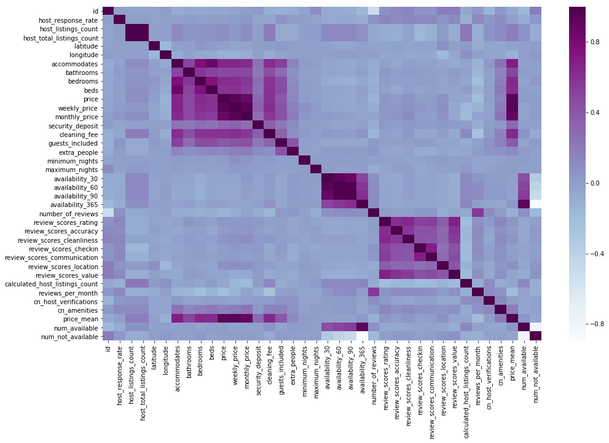

```python
cols = list(df)
corr_ =df[cols].corr()
plt.figure(figsize=(16,10))
sns.heatmap(corr_, annot=False, fmt = ".2f", cmap = "BuPu")
```

**Delete one feature that has a strong correlation with other features**

```python
# Use num available
strong_corr1 = ['availability_30','availability_60','availability_90','availability_365']
for strong_corr1_ in strong_corr1:
    df = df.drop(strong_corr1_, axis=1)

# # Use price mean
strong_corr2 = ['price','weekly_price','monthly_price']
for strong_corr2_ in strong_corr2:
    df = df.drop(strong_corr2_, axis=1)

strong_corr3 = ['review_scores_accuracy','review_scores_cleanliness',
                'review_scores_checkin','review_scores_communication',
               'review_scores_location','review_scores_value']
for strong_corr3_ in strong_corr3:
    df = df.drop(strong_corr3_, axis=1)

# Use host_total_listings_count
df = df.drop('host_listings_count', axis=1)
df = df.drop('reviews_per_month', axis=1)
df = df.drop('extra_people', axis=1)
df = df.drop('accommodates', axis=1)
df = df.drop('id', axis=1)
```

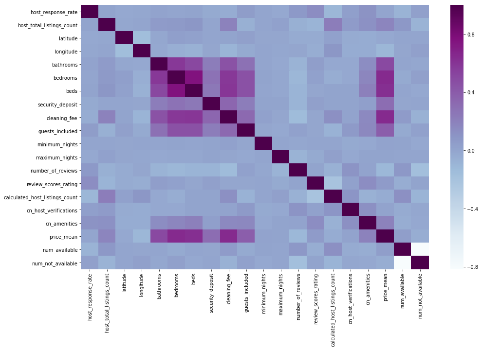

```python
cols = list(df)
corr_ =df[cols].corr()
plt.figure(figsize=(16,10))
sns.heatmap(corr_, annot=False, fmt = ".2f", cmap = "BuPu")
```

### 4.3 Feature Analysis

```python
host_is_superhost = df.groupby('host_is_superhost')['room_type'].count().reset_index()
host_is_superhost.columns = ['host_is_superhost','count']
host_is_superhost = host_is_superhost.sort_values('count', ascending=False).reset_index(drop=True)

cancellation_policy = df.groupby('cancellation_policy')['host_is_superhost'].count().reset_index()
cancellation_policy.columns = ['cancellation_policy','count']
cancellation_policy = cancellation_policy.sort_values('count', ascending=False).reset_index(drop=True)

bedrooms = df.groupby('bedrooms')['host_is_superhost'].count().reset_index()
bedrooms.columns = ['bedrooms','count']
bedrooms = bedrooms.sort_values('count', ascending=False).reset_index(drop=True)

bathrooms = df.groupby('bathrooms')['host_is_superhost'].count().reset_index()
bathrooms.columns = ['bathrooms','count']
bathrooms = bathrooms.sort_values('count', ascending=False).reset_index(drop=True)
```

**host_is_superhost, cancellation_policy, bedrooms, bathrooms Visualization**

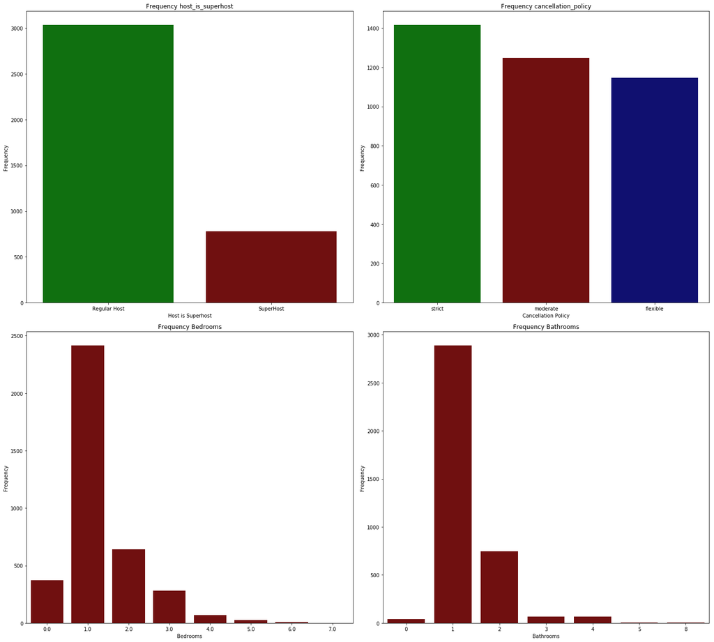

```python
f,ax = plt.subplots(2,2,figsize=(20,18))

g = sns.barplot(x="host_is_superhost",y="count",data=host_is_superhost, ax=ax[0,0], palette=['green', 'maroon'])
ax[0,0].set_title('Frequency host_is_superhost')
ax[0,0].set_xlabel('Host is Superhost')
ax[0,0].set_ylabel('Frequency')

g = sns.barplot(x="cancellation_policy",y="count",data=cancellation_policy, ax=ax[0,1], palette=['green', 'maroon', 'navy'])
ax[0,1].set_title('Frequency cancellation_policy')
ax[0,1].set_xlabel('Cancellation Policy')
ax[0,1].set_ylabel('Frequency')

g = sns.barplot(x="bedrooms",y="count",data=bedrooms, ax=ax[1,0], color = 'maroon')
ax[1,0].set_title('Frequency Bedrooms')
ax[1,0].set_xlabel('Bedrooms')
ax[1,0].set_ylabel('Frequency')

g = sns.barplot(x="bathrooms",y="count",data=bathrooms, ax=ax[1,1], color='maroon')
ax[1,1].set_title('Frequency Bathrooms')
ax[1,1].set_xlabel('Bathrooms')
ax[1,1].set_ylabel('Frequency')

plt.tight_layout()
plt.savefig('../fig/explore 1.png', bbox_inches='tight')
```

```python
bed_type = df.groupby('bed_type')['host_is_superhost'].count().reset_index()
bed_type.columns = ['bed_type','count']
bed_type = bed_type.sort_values('count', ascending=False).reset_index(drop=True)

beds = df.groupby('beds')['host_is_superhost'].count().reset_index()
beds.columns = ['beds','count']

property_type = df.groupby('property_type')['host_is_superhost'].count().reset_index()
property_type.columns = ['property_type','count']
property_type = property_type.sort_values('count', ascending=False).reset_index(drop=True)
property_type = property_type[0:10]

room_type = df.groupby('room_type')['host_is_superhost'].count().reset_index()
room_type.columns = ['room_type','count']
```

**bed_type, beds, property_type, room_type Visualization**

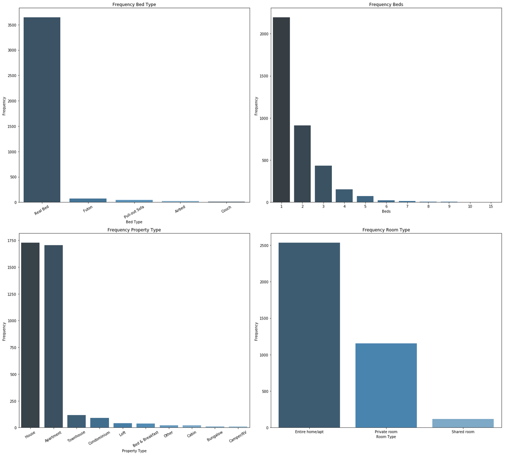

```python
f,ax = plt.subplots(2,2,figsize=(20,18))

g = sns.barplot(x="bed_type",y="count",data=bed_type, ax=ax[0,0],palette=sns.color_palette("Blues_d", n_colors=4, desat=1))
ax[0,0].set_title('Frequency Bed Type')
ax[0,0].set_xlabel('Bed Type')
ax[0,0].set_ylabel('Frequency')
ax[0,0].set_xticklabels(ax[0,0].get_xticklabels(),rotation=30)

g = sns.barplot(x="beds",y="count",data=beds, ax=ax[0,1],palette=sns.color_palette("Blues_d", n_colors=15, desat=1))
ax[0,1].set_title('Frequency Beds')
ax[0,1].set_xlabel('Beds')
ax[0,1].set_ylabel('Frequency')

g = sns.barplot(x="property_type",y="count",data=property_type, ax=ax[1,0], palette=sns.color_palette("Blues_d", n_colors=10, desat=1))
ax[1,0].set_title('Frequency Property Type')
ax[1,0].set_xlabel('Property Type')
ax[1,0].set_ylabel('Frequency')
ax[1,0].set_xticklabels(ax[1,0].get_xticklabels(),rotation=30)

g = sns.barplot(x="room_type",y="count",data=room_type, ax=ax[1,1], palette=sns.color_palette("Blues_d", n_colors=3, desat=1))
ax[1,1].set_title('Frequency Room Type')
ax[1,1].set_xlabel('Room Type')
ax[1,1].set_ylabel('Frequency')

plt.tight_layout()
plt.savefig('../fig/explore 2.png', bbox_inches='tight')
```

**count amenities and review_scores_rating Analysis by host_is_superhost**

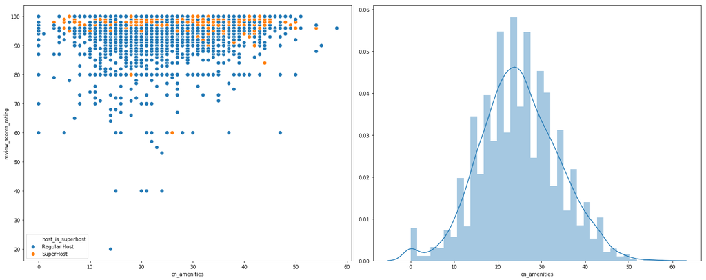

```python
fig, (ax1, ax2) = plt.subplots(nrows=1, ncols=2, figsize=(20,8))
sns.scatterplot(x='cn_amenities',y='review_scores_rating', hue='host_is_superhost', data=df, s=60, ax=ax1)

sns.distplot(df['cn_amenities'], ax=ax2)

plt.tight_layout()
plt.savefig('../fig/rating with cn_amenities.png', bbox_inches='tight')
```

**count available - non available Analysis by review_scores_rating and host_is_superhost**

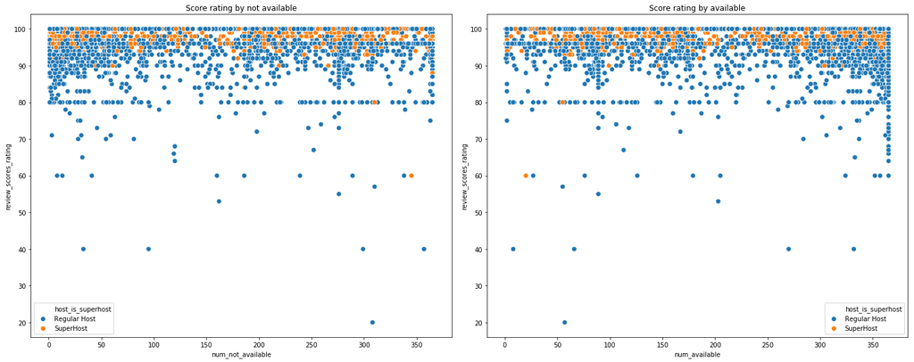

```python
fig, (ax1, ax2) = plt.subplots(nrows=1, ncols=2, figsize=(20,8))
sns.scatterplot(x='num_not_available',y='review_scores_rating', hue='host_is_superhost', data=df, s=60, ax=ax1)
ax1.set_title('Score rating by not available')

sns.scatterplot(x='num_available',y='review_scores_rating', hue='host_is_superhost', data=df, s=60, ax=ax2)
ax2.set_title('Score rating by available')

plt.tight_layout()
plt.savefig('../fig/rating with available.png', bbox_inches='tight')
```

```python
t = pd.read_csv('../input/listings.csv')
t = t[t['host_is_superhost']=='t']
t['review_scores_rating'].describe()
```

```
count    751.000000
mean      97.395473
std        2.624384
min       60.000000
25%       96.000000
50%       98.000000
75%       99.000000
max      100.000000
Name: review_scores_rating, dtype: float64
```

```python
f = pd.read_csv('../input/listings.csv')
f = f[f['host_is_superhost']=='f']
f['review_scores_rating'].describe()
```

```
count    2420.000000
mean       93.652893
std         7.192689
min        20.000000
25%        91.000000
50%        95.000000
75%       100.000000
max       100.000000
Name: review_scores_rating, dtype: float64
```

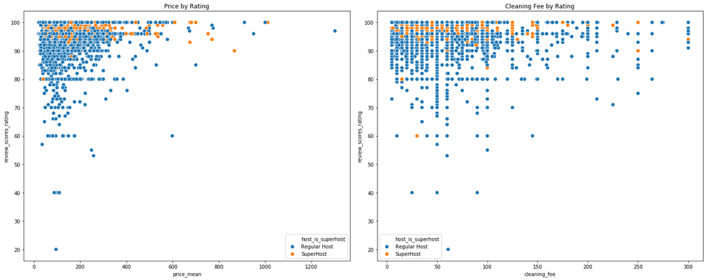

```python
fig, (ax1, ax2) = plt.subplots(nrows=1, ncols=2, figsize=(20,8))
sns.scatterplot(x='price_mean',y='review_scores_rating', hue='host_is_superhost', data=df, s=60, ax=ax1)
ax1.set_title('Price by Rating')

sns.scatterplot(x='cleaning_fee',y='review_scores_rating', hue='host_is_superhost', data=df, s=60, ax=ax2)
ax2.set_title('Cleaning Fee by Rating')

plt.tight_layout()
plt.savefig('../fig/rating with price_mean n cleaning_fee.png', bbox_inches='tight')
```

## 5. Feature Engineering

### 5.1 Categorical Convert

```python
df['p_type'] = np.where((df['property_type']=='House'),0,
            np.where((df['property_type']=='Apartment'),1,
            np.where((df['property_type']=='Townhouse'),2,
            np.where((df['property_type']=='Condominium'),3,
            np.where((df['property_type']=='Loft'),4,
            np.where((df['property_type']=='Bed & Breakfast'),5,
            np.where((df['property_type']=='Other'),6,
            np.where((df['property_type']=='Cabin'),7,
            np.where((df['property_type']=='Bungalow'),8,
            np.where((df['property_type']=='Camper/RV'),9,
            np.where((df['property_type']=='Boat'),10,
            np.where((df['property_type']=='Tent'),11,
            np.where((df['property_type']=='Treehouse'),12,
            np.where((df['property_type']=='Dorm'),13,
            np.where((df['property_type']=='Chalet'),14,15
            )))))))))))))))
df = df.drop('property_type', axis=1)

df["cancellation_policy"] = df["cancellation_policy"].map(
    {'strict': 'cp_strict',
     'moderate': 'cp_moderate',
     'flexible': 'cp_flexible'}
)

cp_df_ = pd.get_dummies(df['cancellation_policy'],prefix = 'cp' )
df = df.assign(cp_strict=cp_df_['cp_cp_strict'],
                cp_moderate=cp_df_['cp_cp_moderate'],
                cp_flexible=cp_df_['cp_cp_flexible']
              )
df = df.drop(['cancellation_policy'], axis=1)

df["bed_type"] = df["bed_type"].map(
    {'Real Bed': 'bed_type_real_bed',
     'Futon': 'bed_type_futon',
     'Pull-out Sofa': 'bed_type_pull_out_sofa',
    'Airbed' : 'bed_type_airbed',
    'Couch' : 'bed_type_couch'}
)

bd_df_ = pd.get_dummies(df['bed_type'],prefix = 'bed_type' )
df = df.assign(bed_type_real_bed=bd_df_['bed_type_bed_type_real_bed'],
                bed_type_futon=bd_df_['bed_type_bed_type_futon'],
                bed_type_pull_out_sofa=bd_df_['bed_type_bed_type_pull_out_sofa'],
                bed_type_airbed=bd_df_['bed_type_bed_type_airbed'],
                bed_type_couch=bd_df_['bed_type_bed_type_couch']
              )
df = df.drop(['bed_type'], axis=1)

df["room_type"] = df["room_type"].map(
    {'Entire home/apt': 'room_type_entire',
     'Private room': 'room_type_private',
     'Shared room': 'room_type_shared'}
)

rt_df_ = pd.get_dummies(df['room_type'],prefix = 'room_type' )
df = df.assign(room_type_entire=rt_df_['room_type_room_type_entire'],
                room_type_private=rt_df_['room_type_room_type_private'],
                room_type_shared=rt_df_['room_type_room_type_shared']
              )
df = df.drop(['room_type'], axis=1)

df["hrt"] = df["host_response_time"]
df = df.drop('host_response_time', axis=1)
df["hrt"] = df["hrt"].map(
    {'within an hour': 'hrt_within_hour',
     'within a few hours': 'hrt_within_few_hours',
     'within a day': 'hrt_within_day',
    'other' : 'hrt_other',
    'a few days or more' : 'hrt_few_days_more'}
)

hrt_df_ = pd.get_dummies(df['hrt'],prefix = 'hrt' )
df = df.assign(hrt_within_hour=hrt_df_['hrt_hrt_within_hour'],
                hrt_within_few_hours=hrt_df_['hrt_hrt_within_few_hours'],
                hrt_within_day=hrt_df_['hrt_hrt_within_day'],
                hrt_other=hrt_df_['hrt_hrt_other'],
                hrt_few_days_more=hrt_df_['hrt_hrt_few_days_more']
              )
df = df.drop(['hrt'], axis=1)

df['require_guest_phone_verification'] = np.where((df['require_guest_phone_verification']=='Not Verified'),1,0)
df['require_guest_profile_picture'] = np.where((df['require_guest_profile_picture']=='f'),1,0)
df['instant_bookable'] = np.where((df['instant_bookable']=='f'),1,0)
df['is_location_exact'] = np.where((df['is_location_exact']=='f'),1,0)
df['host_identity_verified'] = np.where((df['host_identity_verified']=='f'),1,0)
df['host_has_profile_pic'] = np.where((df['host_has_profile_pic']=='f'),1,0)
df['host_is_superhost'] = np.where((df['host_is_superhost']=='SuperHost'),1,0)
df.head()
```

|  | host_response_rate | host_total_listings_count | latitude | longitude | bathrooms | bedrooms | beds | security_deposit | cleaning_fee | guests_included | ... | bed_type_airbed | bed_type_couch | room_type_entire | room_type_private | room_type_shared | hrt_within_hour | hrt_within_few_hours | hrt_within_day | hrt_other | hrt_few_days_more |
| --- | --- | --- | --- | --- | --- | --- | --- | --- | --- | --- | --- | --- | --- | --- | --- | --- | --- | --- | --- | --- | --- |
| 0 | 96.0 | 3.0 | 47.636289 | -122.371025 | 1 | 1.0 | 1 | 250.0 | 50.0 | 2.0 | ... | 0 | 0 | 1 | 0 | 0 | 0 | 1 | 0 | 0 | 0 |
| 1 | 98.0 | 6.0 | 47.639123 | -122.365666 | 1 | 1.0 | 1 | 100.0 | 40.0 | 1.0 | ... | 0 | 0 | 1 | 0 | 0 | 1 | 0 | 0 | 0 | 0 |
| 2 | 67.0 | 2.0 | 47.629724 | -122.369483 | 4 | 5.0 | 7 | 1000.0 | 300.0 | 10.0 | ... | 0 | 0 | 1 | 0 | 0 | 0 | 1 | 0 | 0 | 0 |
| 3 | 100.0 | 1.0 | 47.638473 | -122.369279 | 1 | 0.0 | 2 | 250.0 | 50.0 | 1.0 | ... | 0 | 0 | 1 | 0 | 0 | 0 | 0 | 0 | 1 | 0 |
| 4 | 100.0 | 2.0 | 47.632918 | -122.372471 | 2 | 3.0 | 3 | 700.0 | 125.0 | 6.0 | ... | 0 | 0 | 1 | 0 | 0 | 1 | 0 | 0 | 0 | 0 |

5 rows × 44 columns

```python
# df.to_csv('../input/dataset.csv',index=False)
```